# 클린업1주차패키지

#문제0번 기본세팅

```r
library(plyr)
library(tidyverse)
library(data.table)
setwd("C:\\Users\\User\\Desktop\\P-SAT\\1주차패키지")
data<-fread("data.csv")
```

**#CHAPTER1#**  
#문제1번 데이터확인하기

```r
data %>% is.na() %>% colSums
```

```
##     patient_id            sex            age        country       province
##              0              0              0              0              0
##           city confirmed_date          state
##              0              3              0
```

```r
data %>% unique() %>% head()
```

```
##    patient_id    sex age country province   city confirmed_date    state
## 1: 1000000001   male 50s   Korea     서울 강서구     2020-01-23 released
## 2: 1000000002   male 30s   Korea     서울 중랑구     2020-01-30 released
## 3: 1000000003   male 50s   Korea     서울 종로구     2020-01-30 released
## 4: 1000000004   male 20s   Korea     서울 마포구     2020-01-30 released
## 5: 1000000005 female 20s   Korea     서울 성북구     2020-01-31 released
## 6: 1000000006 female 50s   Korea     서울 종로구     2020-01-31 released
```

```r
dfdata<-data %>% data.frame()
for(i in 1:8){
  len<-dfdata[,i] %>% unique() %>% length()
  nacol<-colnames(dfdata)
  cat(i,'열',nacol[i],'의 유니크한 값의 개수는',len,'개\n')
}
```

```
## 1 열 patient_id 의 유니크한 값의 개수는 5164 개
## 2 열 sex 의 유니크한 값의 개수는 3 개
## 3 열 age 의 유니크한 값의 개수는 12 개
## 4 열 country 의 유니크한 값의 개수는 16 개
## 5 열 province 의 유니크한 값의 개수는 17 개
## 6 열 city 의 유니크한 값의 개수는 163 개
## 7 열 confirmed_date 의 유니크한 값의 개수는 149 개
## 8 열 state 의 유니크한 값의 개수는 3 개
```

#문제2-1번 NA가 있는 행 삭제

```r
nona<-data %>% filter(!is.na(confirmed_date))
nona %>% head()
```

```
##    patient_id    sex age country province   city confirmed_date    state
## 1: 1000000001   male 50s   Korea     서울 강서구     2020-01-23 released
## 2: 1000000002   male 30s   Korea     서울 중랑구     2020-01-30 released
## 3: 1000000003   male 50s   Korea     서울 종로구     2020-01-30 released
## 4: 1000000004   male 20s   Korea     서울 마포구     2020-01-30 released
## 5: 1000000005 female 20s   Korea     서울 성북구     2020-01-31 released
## 6: 1000000006 female 50s   Korea     서울 종로구     2020-01-31 released
```

```r
nona %>% is.na() %>% colSums
```

```
##     patient_id            sex            age        country       province
##              0              0              0              0              0
##           city confirmed_date          state
##              0              0              0
```

#문제2-2번 빈 문자열(“”)이 있는 행을 삭제하고, 각 열마다 NA 개수와 unique 값 및 개수를 다시 확인해 보세요

```r
nona[nona==""]<-NA
nona %>% is.na() %>% colSums
```

```
##     patient_id            sex            age        country       province
##              0           1122           1380              0              0
##           city confirmed_date          state
##             94              0              0
```

```r
nona<-nona %>% filter(!is.na(sex))
nona<-nona %>% filter(!is.na(age))
nona<-nona %>% filter(!is.na(city))
nona %>% head()
```

```
##    patient_id    sex age country province   city confirmed_date    state
## 1: 1000000001   male 50s   Korea     서울 강서구     2020-01-23 released
## 2: 1000000002   male 30s   Korea     서울 중랑구     2020-01-30 released
## 3: 1000000003   male 50s   Korea     서울 종로구     2020-01-30 released
## 4: 1000000004   male 20s   Korea     서울 마포구     2020-01-30 released
## 5: 1000000005 female 20s   Korea     서울 성북구     2020-01-31 released
## 6: 1000000006 female 50s   Korea     서울 종로구     2020-01-31 released
```

```r
nona %>% is.na() %>% colSums
```

```
##     patient_id            sex            age        country       province
##              0              0              0              0              0
##           city confirmed_date          state
##              0              0              0
```

```r
nona<-nona %>% data.frame()
nona %>% unique() %>% head()
```

```
##   patient_id    sex age country province   city confirmed_date    state
## 1 1000000001   male 50s   Korea     서울 강서구     2020-01-23 released
## 2 1000000002   male 30s   Korea     서울 중랑구     2020-01-30 released
## 3 1000000003   male 50s   Korea     서울 종로구     2020-01-30 released
## 4 1000000004   male 20s   Korea     서울 마포구     2020-01-30 released
## 5 1000000005 female 20s   Korea     서울 성북구     2020-01-31 released
## 6 1000000006 female 50s   Korea     서울 종로구     2020-01-31 released
```

```r
for(i in 1:8){
  newlen<-nona[,i] %>% unique() %>% length()
  nacol2<-colnames(nona)
  cat(i,'열',nacol2[i],'의 유니크한 값의 개수는',newlen,'개\n')
}
```

```
## 1 열 patient_id 의 유니크한 값의 개수는 3689 개
## 2 열 sex 의 유니크한 값의 개수는 2 개
## 3 열 age 의 유니크한 값의 개수는 11 개
## 4 열 country 의 유니크한 값의 개수는 15 개
## 5 열 province 의 유니크한 값의 개수는 16 개
## 6 열 city 의 유니크한 값의 개수는 158 개
## 7 열 confirmed_date 의 유니크한 값의 개수는 145 개
## 8 열 state 의 유니크한 값의 개수는 3 개
```

#문제3번 country가 ‘Korea’인 행만 남긴 다음, country 열을 제거하세요

```r
nona<-nona %>% filter(nona$country=='Korea') %>% select(-country)
nona %>% head()
```

```
##   patient_id    sex age province   city confirmed_date    state
## 1 1000000001   male 50s     서울 강서구     2020-01-23 released
## 2 1000000002   male 30s     서울 중랑구     2020-01-30 released
## 3 1000000003   male 50s     서울 종로구     2020-01-30 released
## 4 1000000004   male 20s     서울 마포구     2020-01-30 released
## 5 1000000005 female 20s     서울 성북구     2020-01-31 released
## 6 1000000006 female 50s     서울 종로구     2020-01-31 released
```

#문제4번 province 변수 내 ‘서울, 부산, 대구, 인천, 대전, 세종, 울산, 제주도’ 값을 다음과 같이 바꾸세요

```r
nona$province[nona$province=='서울']<-'서울특별시'
nona$province[nona$province=='부산']<-'부산광역시'
nona$province[nona$province=='대구']<-'대구광역시'
nona$province[nona$province=='인천']<-'인천광역시'
nona$province[nona$province=='대전']<-'대전광역시'
nona$province[nona$province=='세종']<-'세종특별자치시'
nona$province[nona$province=='울산']<-'울산광역시'
nona$province[nona$province=='제주도']<-'제주도특별자치도'
nona %>% head()
```

```
##   patient_id    sex age   province   city confirmed_date    state
## 1 1000000001   male 50s 서울특별시 강서구     2020-01-23 released
## 2 1000000002   male 30s 서울특별시 중랑구     2020-01-30 released
## 3 1000000003   male 50s 서울특별시 종로구     2020-01-30 released
## 4 1000000004   male 20s 서울특별시 마포구     2020-01-30 released
## 5 1000000005 female 20s 서울특별시 성북구     2020-01-31 released
## 6 1000000006 female 50s 서울특별시 종로구     2020-01-31 released
```

#문제5번 confirmed_date를 날짜 자료형(Date)으로 바꾸세요

```r
nona$confirmed_date<-as.Date(nona$confirmed_date)
nona %>% head()
```

```
##   patient_id    sex age   province   city confirmed_date    state
## 1 1000000001   male 50s 서울특별시 강서구     2020-01-23 released
## 2 1000000002   male 30s 서울특별시 중랑구     2020-01-30 released
## 3 1000000003   male 50s 서울특별시 종로구     2020-01-30 released
## 4 1000000004   male 20s 서울특별시 마포구     2020-01-30 released
## 5 1000000005 female 20s 서울특별시 성북구     2020-01-31 released
## 6 1000000006 female 50s 서울특별시 종로구     2020-01-31 released
```

#문제6번 확진날짜(confirmed_date) 별 확진자 수에 대한 파생변수를 만드세요. (파생변수 이름 : confirmed_number)

```r
nona<-nona %>% group_by(confirmed_date) %>% mutate(confirmed_number=n())
nona %>% head()
```

```
## # A tibble: 6 x 8
## # Groups:   confirmed_date [3]
##   patient_id sex    age   province  city  confirmed_date state  confirmed_number
##      <int64> <chr>  <chr> <chr>     <chr> <date>         <chr>             <int>
## 1 1000000001 male   50s   서울특별시~ 강서구~ 2020-01-23     relea~                1
## 2 1000000002 male   30s   서울특별시~ 중랑구~ 2020-01-30     relea~                4
## 3 1000000003 male   50s   서울특별시~ 종로구~ 2020-01-30     relea~                4
## 4 1000000004 male   20s   서울특별시~ 마포구~ 2020-01-30     relea~                4
## 5 1000000005 female 20s   서울특별시~ 성북구~ 2020-01-31     relea~                3
## 6 1000000006 female 50s   서울특별시~ 종로구~ 2020-01-31     relea~                3
```

#문제7번 확진날짜(confirmed_date)의 주말 여부에 대한 파생변수를 만드세요. (파생변수 이름 : wday)

```r
nona<-nona %>% mutate(wday=ifelse(wday(confirmed_date)%in%c(1,7),'주말','주중'))
nona %>% head()
```

```
## # A tibble: 6 x 9
## # Groups:   confirmed_date [3]
##   patient_id sex   age   province city  confirmed_date state confirmed_number
##      <int64> <chr> <chr> <chr>    <chr> <date>         <chr>            <int>
## 1 1000000001 male  50s   서울특별시~ 강서구~ 2020-01-23     rele~                1
## 2 1000000002 male  30s   서울특별시~ 중랑구~ 2020-01-30     rele~                4
## 3 1000000003 male  50s   서울특별시~ 종로구~ 2020-01-30     rele~                4
## 4 1000000004 male  20s   서울특별시~ 마포구~ 2020-01-30     rele~                4
## 5 1000000005 fema~ 20s   서울특별시~ 성북구~ 2020-01-31     rele~                3
## 6 1000000006 fema~ 50s   서울특별시~ 종로구~ 2020-01-31     rele~                3
## # ... with 1 more variable: wday <chr>
```

#문제8번 나이대 별 일별 확진자 수에 대한 summary를 확인해 보세요. (예 : 10대의 날짜별 확진자 수의 분포)

```r
summary<-nona %>% group_by(age,confirmed_date) %>% summarise(confirmed_number=n()) %>% as.data.frame()
tapply(summary$confirmed_number,summary$age,summary)
```

```
## $`0s`
##    Min. 1st Qu.  Median    Mean 3rd Qu.    Max.
##   1.000   1.000   1.000   1.488   2.000   3.000
##
## $`100s`
##    Min. 1st Qu.  Median    Mean 3rd Qu.    Max.
##       1       1       1       1       1       1
##
## $`10s`
##    Min. 1st Qu.  Median    Mean 3rd Qu.    Max.
##   1.000   1.000   2.000   2.276   3.000   8.000
##
## $`20s`
##    Min. 1st Qu.  Median    Mean 3rd Qu.    Max.
##   1.000   1.000   3.500   7.526  11.000  43.000
##
## $`30s`
##    Min. 1st Qu.  Median    Mean 3rd Qu.    Max.
##   1.000   2.000   3.000   5.051   8.000  17.000
##
## $`40s`
##    Min. 1st Qu.  Median    Mean 3rd Qu.    Max.
##   1.000   1.000   2.000   4.931   6.000  33.000
##
## $`50s`
##    Min. 1st Qu.  Median    Mean 3rd Qu.    Max.
##   1.000   1.000   3.000   6.112   9.000  31.000
##
## $`60s`
##    Min. 1st Qu.  Median    Mean 3rd Qu.    Max.
##   1.000   1.000   3.000   4.722   7.000  22.000
##
## $`70s`
##    Min. 1st Qu.  Median    Mean 3rd Qu.    Max.
##   1.000   1.000   2.000   2.908   3.250  13.000
##
## $`80s`
##    Min. 1st Qu.  Median    Mean 3rd Qu.    Max.
##   1.000   1.000   2.000   3.019   3.750  24.000
##
## $`90s`
##    Min. 1st Qu.  Median    Mean 3rd Qu.    Max.
##   1.000   1.000   1.000   2.286   2.000  16.000
```

**#CHAPTER2#** #문제1번 Line Plot. confirmed_date와 confirmed_number 변수를 이용하여 확진자수 추이 그래프를 그리고, 최대 확진자에 대한 정보도 표시하세요.

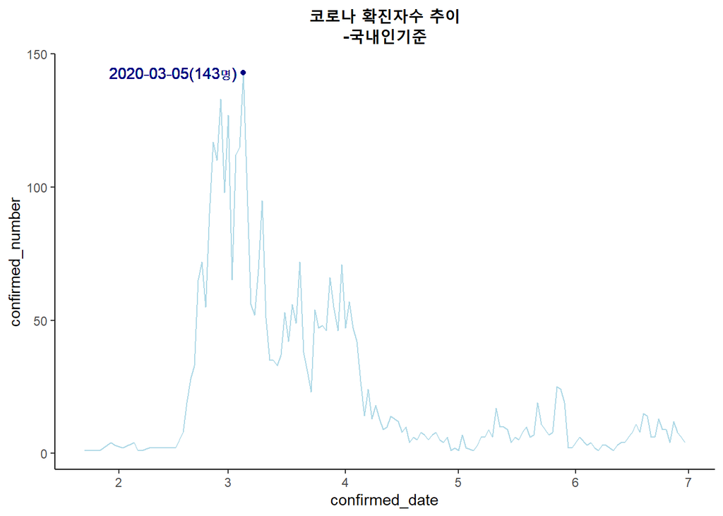

```r
library(ggplot2)
nona<-data.frame(nona)
first<-ggplot(nona,aes(x=confirmed_date, y=confirmed_number))+
  geom_line(color="lightblue")+
  theme_classic()+
  geom_point(aes(x=confirmed_date[which.max(confirmed_number)],y=max(confirmed_number)),color="navy")+
  labs(title='코로나 확진자수 추이\n-국내인기준')+theme(plot.title=element_text(hjust=0.5,face="bold"))+
  geom_text(aes(x=confirmed_date[which.max(confirmed_number)],y=max(confirmed_number)), label="2020-03-05(143명)", color='navy',hjust=1.05)
first
```

#문제1-2번 province 별 확진자 수 추이 그래프를 그리세요.

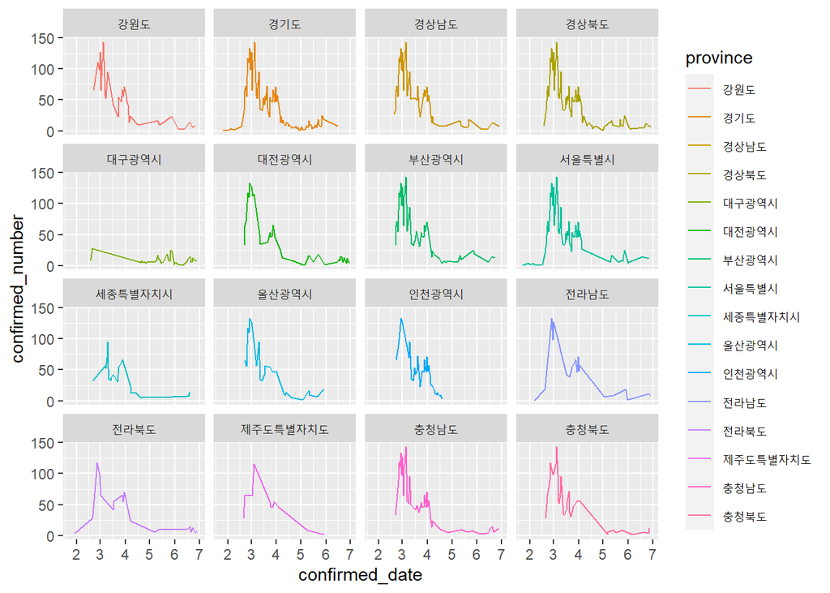

```r
second<-ggplot(nona, aes(x=confirmed_date,y=confirmed_number))+geom_line(aes(color=province, group=province))+facet_wrap(vars(province),nrow=4)
second
```

#문제2번 Bar Plot. 지역별 확진자 수를 state(확진자 상황) 그룹 별로 나누어 그래프를 그리세요

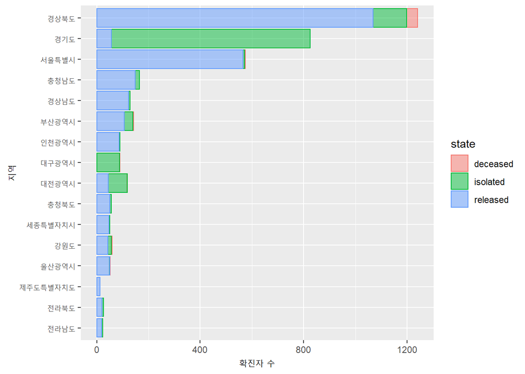

```r
nona %>% group_by(province,state) %>% summarise(n=n()) %>% ggplot()+geom_bar(aes(x=n,y=reorder(province,n),fill=state,color=state),stat="identity",alpha=0.5)+labs(x='확진자 수',y='지역')
```

#문제3번 Box Plot. 나이대별 일별 확진자 수 box plot을 그리세요

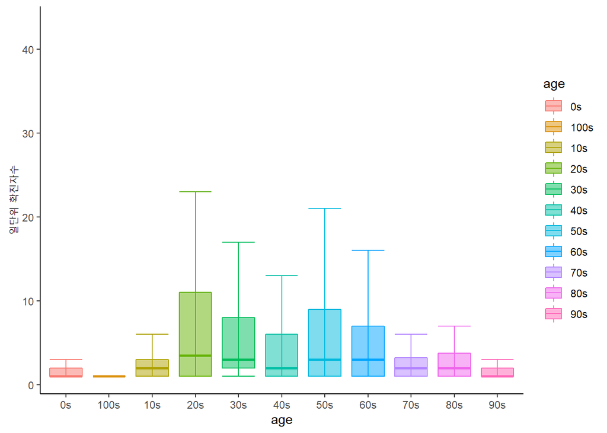

```r
Bx<-summary %>% ggplot(aes(x=age,y=confirmed_number))+geom_boxplot(aes(color=age, fill=age), alpha=0.5,outlier.size=-1)+labs(y='일단위 확진자수')+theme_classic()+stat_boxplot(geom='errorbar',aes(color=age))
Bx
```

#문제3-2번 나이대별 일별 확진자 수에 대한 일원분산분석(one-way ANOVA)을 실시하여 해석해 보세요

```r
summary(anotest<-aov(confirmed_number~age, data=summary))
```

```
##              Df Sum Sq Mean Sq F value   Pr(>F)
## age          10   2575  257.48   8.823 8.19e-14 ***
## Residuals   780  22764   29.18
## ---
## Signif. codes:  0 '***' 0.001 '**' 0.01 '*' 0.05 '.' 0.1 ' ' 1
```

```r
anotest
```

```
## Call:
##    aov(formula = confirmed_number ~ age, data = summary)
##
## Terms:
##                       age Residuals
## Sum of Squares   2574.808 22763.890
## Deg. of Freedom        10       780
##
## Residual standard error: 5.402266
## Estimated effects may be unbalanced
```

**#CHAPTER3#** #문제1번 상관계수 플랏을 만들고 간단히 해석해 보세요.

```r
library(MASS)
```

```r
library(tidyverse)
library(corrplot)
library(caret)
library(MLmetrics)
Bdata<-Boston %>% select_if(is.numeric) %>% cor()
Bdata
```

```
##                crim          zn       indus         chas         nox
## crim     1.00000000 -0.20046922  0.40658341 -0.055891582  0.42097171
## zn      -0.20046922  1.00000000 -0.53382819 -0.042696719 -0.51660371
## indus    0.40658341 -0.53382819  1.00000000  0.062938027  0.76365145
## chas    -0.05589158 -0.04269672  0.06293803  1.000000000  0.09120281
## nox      0.42097171 -0.51660371  0.76365145  0.091202807  1.00000000
## rm      -0.21924670  0.31199059 -0.39167585  0.091251225 -0.30218819
## age      0.35273425 -0.56953734  0.64477851  0.086517774  0.73147010
## dis     -0.37967009  0.66440822 -0.70802699 -0.099175780 -0.76923011
## rad      0.62550515 -0.31194783  0.59512927 -0.007368241  0.61144056
## tax      0.58276431 -0.31456332  0.72076018 -0.035586518  0.66802320
## ptratio  0.28994558 -0.39167855  0.38324756 -0.121515174  0.18893268
## black   -0.38506394  0.17552032 -0.35697654  0.048788485 -0.38005064
## lstat    0.45562148 -0.41299457  0.60379972 -0.053929298  0.59087892
## medv    -0.38830461  0.36044534 -0.48372516  0.175260177 -0.42732077
##                  rm         age         dis          rad         tax    ptratio
## crim    -0.21924670  0.35273425 -0.37967009  0.625505145  0.58276431  0.2899456
## zn       0.31199059 -0.56953734  0.66440822 -0.311947826 -0.31456332 -0.3916785
## indus   -0.39167585  0.64477851 -0.70802699  0.595129275  0.72076018  0.3832476
## chas     0.09125123  0.08651777 -0.09917578 -0.007368241 -0.03558652 -0.1215152
## nox     -0.30218819  0.73147010 -0.76923011  0.611440563  0.66802320  0.1889327
## rm       1.00000000 -0.24026493  0.20524621 -0.209846668 -0.29204783 -0.3555015
## age     -0.24026493  1.00000000 -0.74788054  0.456022452  0.50645559  0.2615150
## dis      0.20524621 -0.74788054  1.00000000 -0.494587930 -0.53443158 -0.2324705
## rad     -0.20984667  0.45602245 -0.49458793  1.000000000  0.91022819  0.4647412
## tax     -0.29204783  0.50645559 -0.53443158  0.910228189  1.00000000  0.4608530
## ptratio -0.35550149  0.26151501 -0.23247054  0.464741179  0.46085304  1.0000000
## black    0.12806864 -0.27353398  0.29151167 -0.444412816 -0.44180801 -0.1773833
## lstat   -0.61380827  0.60233853 -0.49699583  0.488676335  0.54399341  0.3740443
## medv     0.69535995 -0.37695457  0.24992873 -0.381626231 -0.46853593 -0.5077867
##               black      lstat       medv
## crim    -0.38506394  0.4556215 -0.3883046
## zn       0.17552032 -0.4129946  0.3604453
## indus   -0.35697654  0.6037997 -0.4837252
## chas     0.04878848 -0.0539293  0.1752602
## nox     -0.38005064  0.5908789 -0.4273208
## rm       0.12806864 -0.6138083  0.6953599
## age     -0.27353398  0.6023385 -0.3769546
## dis      0.29151167 -0.4969958  0.2499287
## rad     -0.44441282  0.4886763 -0.3816262
## tax     -0.44180801  0.5439934 -0.4685359
## ptratio -0.17738330  0.3740443 -0.5077867
## black    1.00000000 -0.3660869  0.3334608
## lstat   -0.36608690  1.0000000 -0.7376627
## medv     0.33346082 -0.7376627  1.0000000
```

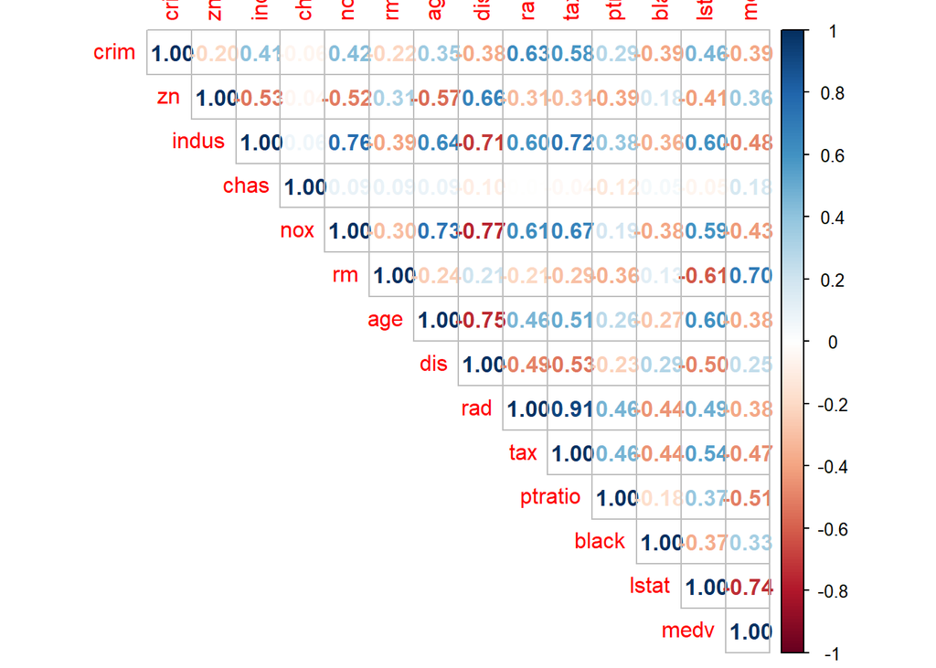

```r
corrplot(Bdata,type="upper",method="number")
```

#문제2번 아래와 같이 종속변수로 사용할 medv와 이외 변수 간의 관계 파악을 위한 scatterplot 및 회귀 추세선을 그려보세요.

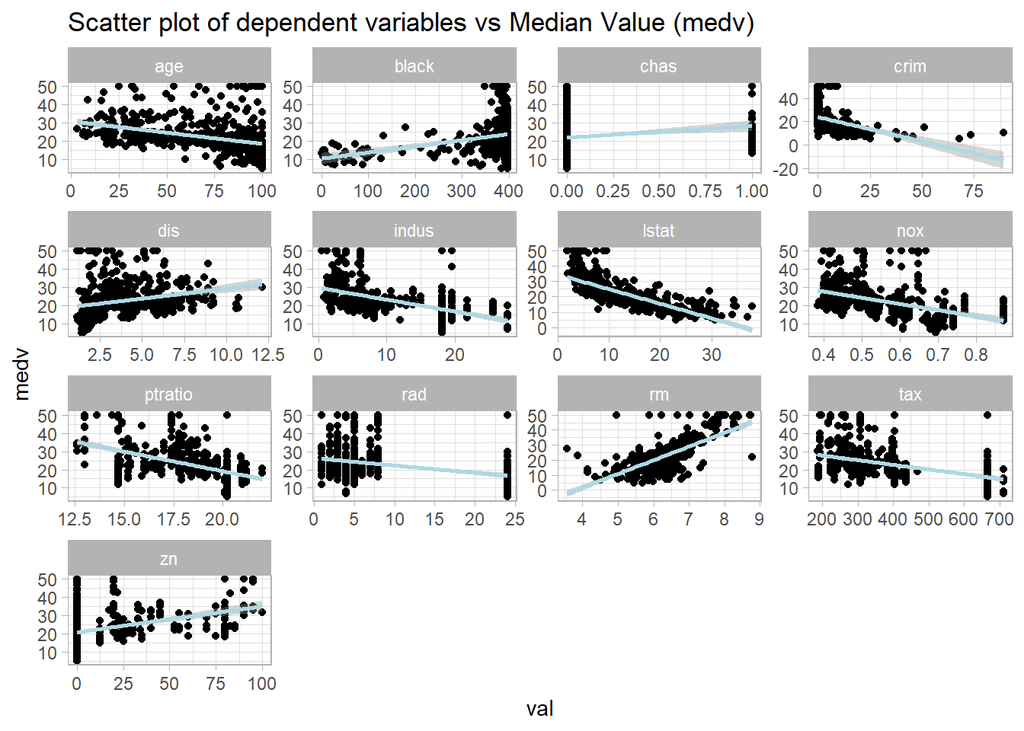

```r
Boston<-as.data.frame(Boston)
Boston %>% gather(-medv,key="var",value="val") %>% ggplot(aes(x=val,y=medv))+geom_point()+facet_wrap(~var,nrow=4,scale='free')+theme_light()+labs(title="Scatter plot of dependent variables vs Median Value (medv)")+stat_smooth(color="lightblue", method="lm")
```

#문제3번 데이터를 train/test 데이터를 7:3으로 나누세요 (1234로 시드 고정 필수)

```r
set.seed(1234)
sample.size <- floor(0.7 * nrow(Boston))
train.index <- sample(seq_len(nrow(Boston)), size = sample.size)
train <- Boston[train.index, ]
test <- Boston[- train.index, ]
nrow(train)
```

```
## [1] 354
```

```r
nrow(test)
```

```
## [1] 152
```

#문제3-2번 train 데이터로 medv를 종속변수로 하고 나머지를 모두 독립 변수로 하는 회귀 모형을 만든 후 간단히 결과를 해석한 후, test에 대한 RMSE를 구하세요

```r
lm.fit=lm(medv~.,data=train)
summary(lm.fit)
```

```
##
## Call:
## lm(formula = medv ~ ., data = train)
##
## Residuals:
##      Min       1Q   Median       3Q      Max
## -16.2210  -2.5130  -0.7122   1.8295  26.9382
##
## Coefficients:
##               Estimate Std. Error t value Pr(>|t|)
## (Intercept)  26.399485   6.347070   4.159 4.05e-05 ***
## crim         -0.111639   0.035323  -3.160 0.001717 **
## zn            0.044388   0.015841   2.802 0.005367 **
## indus        -0.008549   0.071304  -0.120 0.904641
## chas          2.793031   0.972463   2.872 0.004333 **
## nox         -17.494132   4.314041  -4.055 6.22e-05 ***
## rm            4.907947   0.542364   9.049  < 2e-16 ***
## age          -0.016715   0.015386  -1.086 0.278074
## dis          -1.441577   0.229553  -6.280 1.03e-09 ***
## rad           0.254051   0.075422   3.368 0.000843 ***
## tax          -0.011540   0.004309  -2.678 0.007765 **
## ptratio      -0.838551   0.154130  -5.441 1.02e-07 ***
## black         0.009602   0.003200   3.000 0.002896 **
## lstat        -0.341352   0.062357  -5.474 8.55e-08 ***
## ---
## Signif. codes:  0 '***' 0.001 '**' 0.01 '*' 0.05 '.' 0.1 ' ' 1
##
## Residual standard error: 4.656 on 340 degrees of freedom
## Multiple R-squared:  0.7508, Adjusted R-squared:  0.7413
## F-statistic: 78.79 on 13 and 340 DF,  p-value: < 2.2e-16
```

```r
predictions<-lm.fit %>% predict(test[,-14])
RMSE(predictions,test$medv)
```

```
## [1] 5.167506
```

#문제3-3 모델의 RMSE를 낮출 수 있는 방법에 대해 간략히 설명해 주세요. 1.obs의 수, 즉 표본을 많이 확보한다. 2.Bootstrap 또는 Cross Validation 을 통해 여러 모델 중 test RMSE 값이 가장 낮은 모델을 선택한다.

#문제4번 적합한 회귀모형의 계수에 대해 아래와 같이 시각화 해주세요

```r
lm.fit
```

```
##
## Call:
## lm(formula = medv ~ ., data = train)
##
## Coefficients:
## (Intercept)         crim           zn        indus         chas          nox
##   26.399485    -0.111639     0.044388    -0.008549     2.793031   -17.494132
##          rm          age          dis          rad          tax      ptratio
##    4.907947    -0.016715    -1.441577     0.254051    -0.011540    -0.838551
##       black        lstat
##    0.009602    -0.341352
```

```r
dffit<-lm.fit$coefficients %>% as.data.frame()
dffit$cols=rownames(dffit)
colnames(dffit)=c("value","val")
dffit
```

```
##                     value         val
## (Intercept)  26.399484614 (Intercept)
## crim         -0.111639110        crim
## zn            0.044387709          zn
## indus        -0.008548619       indus
## chas          2.793030953        chas
## nox         -17.494131772         nox
## rm            4.907947014          rm
## age          -0.016715003         age
## dis          -1.441576855         dis
## rad           0.254050582         rad
## tax          -0.011540215         tax
## ptratio      -0.838550789     ptratio
## black         0.009602500       black
## lstat        -0.341351891       lstat
```

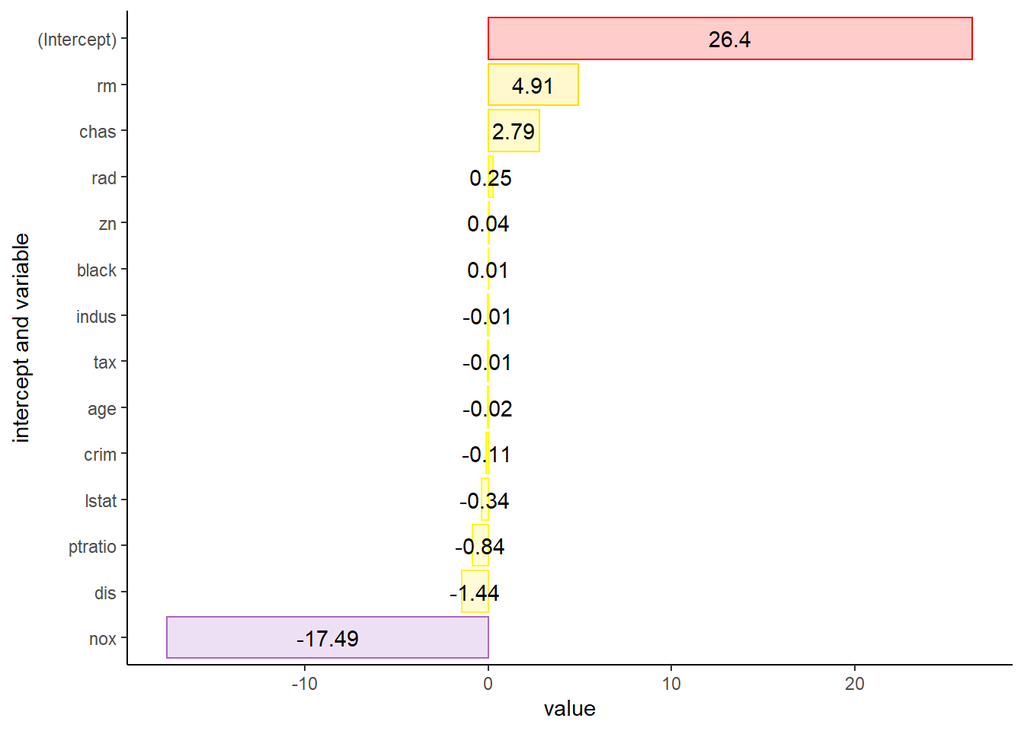

```r
dffit %>% ggplot(aes(x=value, y=reorder(val,value),fill=value,color=value))+
  geom_bar(stat = 'identity',alpha=0.2)+
  theme_classic()+labs(x='value',y='intercept and variable')+
  scale_color_gradient2(low="blue", mid="yellow",high="red")+
  scale_fill_gradient2(low="blue", mid="yellow",high="red")+
  theme(legend.position = 'none') +
  geom_text(aes(label = round(value,2)),color="black",position=position_stack(0.5))
```